# HW10

## Problem 1

```r
library(alr4)
library(carData)
data(Moore)
head(Moore)
```

```
##   partner.status conformity fcategory fscore
## 1            low          8       low     37
## 2            low          4      high     57
## 3            low          8      high     65
## 4            low          7       low     20
## 5            low         10       low     36
## 6            low          6       low     18
```

```r
attach(Moore)
as.factor(partner.status)
```

```
##  [1] low  low  low  low  low  low  low  low  low  low  low  low  low  low  low
## [16] low  low  low  low  low  low  low  high high high high high high high high
## [31] high high high high high high high high high high high high high high high
## Levels: high low
```

```r
as.factor(fcategory)
```

```
##  [1] low    high   high   low    low    low    medium medium low    low
## [11] medium high   low    medium high   high   low    high   high   high
## [21] low    low    high   medium low    high   low    high   medium medium
## [31] high   medium low    medium medium low    high   medium medium medium
## [41] medium high   low    high   medium
## Levels: high low medium
```

1. Some predictor’s P-value is not significant, which means this model has redundant predictor.

```r
Moore_model = lm(conformity~partner.status+fcategory+partner.status:fcategory)
summary(Moore_model)
```

```
##
## Call:
## lm(formula = conformity ~ partner.status + fcategory + partner.status:fcategory)
##
## Residuals:
##     Min      1Q  Median      3Q     Max
## -8.6250 -2.9000 -0.2727  2.7273 11.3750
##
## Coefficients:
##                                   Estimate Std. Error t value Pr(>|t|)
## (Intercept)                        11.8571     1.7307   6.851 3.44e-08 ***
## partner.statuslow                   0.7679     2.3699   0.324   0.7477
## fcategorylow                        5.5429     2.6813   2.067   0.0454 *
## fcategorymedium                     2.4156     2.2140   1.091   0.2819
## partner.statuslow:fcategorylow     -9.2679     3.4507  -2.686   0.0106 *
## partner.statuslow:fcategorymedium  -7.7906     3.5728  -2.181   0.0353 *
## ---
## Signif. codes:  0 '***' 0.001 '**' 0.01 '*' 0.05 '.' 0.1 ' ' 1
##
## Residual standard error: 4.579 on 39 degrees of freedom
## Multiple R-squared:  0.3237, Adjusted R-squared:  0.237
## F-statistic: 3.734 on 5 and 39 DF,  p-value: 0.007397
```

2. “anova” tests using TypeI while “Anova” test using TypeII. TypeII test doesn’t care about interaction term. We can see fcategory should be dropped.

```r
anova(Moore_model)
```

```
## Analysis of Variance Table
##
## Response: conformity
##                          Df Sum Sq Mean Sq F value   Pr(>F)
## partner.status            1 204.33 204.332  9.7448 0.003381 **
## fcategory                 2  11.61   5.807  0.2770 0.759564
## partner.status:fcategory  2 175.49  87.744  4.1846 0.022572 *
## Residuals                39 817.76  20.968
## ---
## Signif. codes:  0 '***' 0.001 '**' 0.01 '*' 0.05 '.' 0.1 ' ' 1
```

```r
Anova(Moore_model, type="II")
```

```
## Anova Table (Type II tests)
##
## Response: conformity
##                          Sum Sq Df F value   Pr(>F)
## partner.status           212.21  1 10.1207 0.002874 **
## fcategory                 11.61  2  0.2770 0.759564
## partner.status:fcategory 175.49  2  4.1846 0.022572 *
## Residuals                817.76 39
## ---
## Signif. codes:  0 '***' 0.001 '**' 0.01 '*' 0.05 '.' 0.1 ' ' 1
```

(3)Those p-values are not significant. So this tells us those mean fcategory dont’t work well.

```r
tmp <- aov(conformity~partner.status*fcategory,data=Moore)
TukeyHSD(tmp,which="fcategory")
```

```
##   Tukey multiple comparisons of means
##     95% family-wise confidence level
##
## Fit: aov(formula = conformity ~ partner.status * fcategory, data = Moore)
##
## $fcategory
##                    diff       lwr      upr     p adj
## low-high     0.03504611 -4.038599 4.108691 0.9997578
## medium-high -1.00342556 -5.077071 3.070220 0.8208662
## medium-low  -1.03847167 -5.112117 3.035173 0.8095010
```

## Problem2

1. We can say most of predictors has collinearity to another predictor.

```r
head(Rpdata)
```

```
##          y        x1         x2         x3        x4         x5       x6
## 1  0.31680 -0.034611 -0.0635220  0.0437570 -0.030642  0.1303200 -0.56870
## 2 -0.58091 -0.028196  0.2368700 -0.1884600  0.190510 -0.0818980  0.29123
## 3 -0.38789  0.059727  0.0884460 -0.0946590  0.022736  0.0073608  0.40923
## 4 -0.31245  0.052236  0.0032441 -0.1222200  0.127780  0.0471430 -0.64441
## 5  0.96025 -0.057986  0.0659260 -0.0070171  0.107700  0.1265700 -0.71757
## 6  1.18400  0.189340 -0.4765500  0.1547300 -0.321130  0.0726280 -0.13887
```

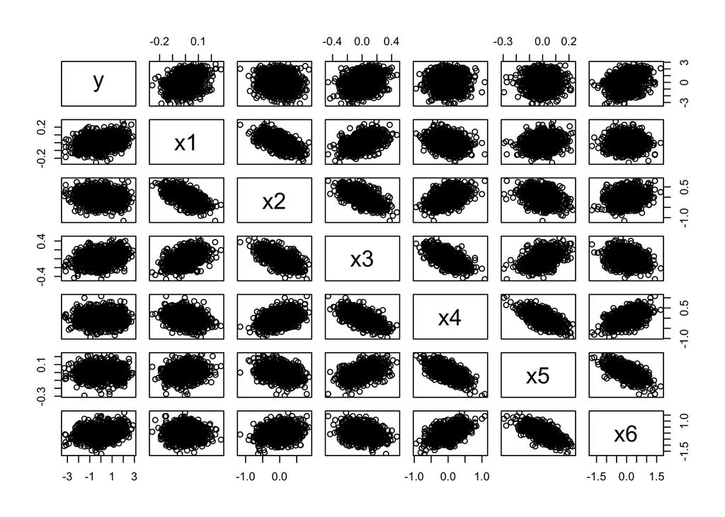

```r
attach(Rpdata)
plot(Rpdata)
```

2. All of predictors are significant in spite of having collinearity.

```r
rp_model = lm(y~x1+x2+x3+x4+x5+x6)
summary(rp_model)
```

```
##
## Call:
## lm(formula = y ~ x1 + x2 + x3 + x4 + x5 + x6)
##
## Residuals:
##     Min      1Q  Median      3Q     Max
## -2.1977 -0.7631  0.1729  0.8851  1.6359
##
## Coefficients:
##             Estimate Std. Error t value Pr(>|t|)
## (Intercept)  0.02481    0.03188   0.778    0.437
## x1           4.14061    0.50954   8.126 1.32e-15 ***
## x2           1.01233    0.15522   6.522 1.11e-10 ***
## x3           3.99614    0.32663  12.234  < 2e-16 ***
## x4           0.96045    0.16657   5.766 1.09e-08 ***
## x5           3.75122    0.64726   5.796 9.17e-09 ***
## x6           0.95390    0.08561  11.142  < 2e-16 ***
## ---
## Signif. codes:  0 '***' 0.001 '**' 0.01 '*' 0.05 '.' 0.1 ' ' 1
##
## Residual standard error: 1.003 on 983 degrees of freedom
## Multiple R-squared:  0.3112, Adjusted R-squared:  0.307
## F-statistic: 74.03 on 6 and 983 DF,  p-value: < 2.2e-16
```

3. Apprently this looks strange.

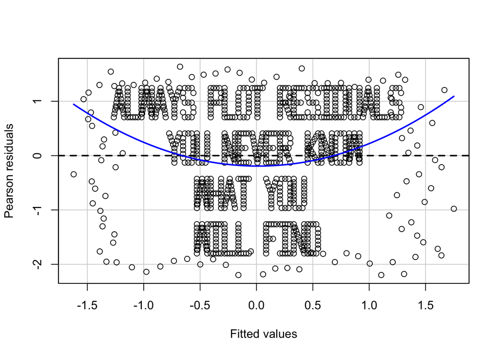

```r
residualPlot(rp_model)
```

## Problem3

1. This linear model looks fitted well and summary also shows.

```r
head(pipeline)
```

```
##   Field  Lab Batch
## 1    18 20.2     1
## 2    38 56.0     1
## 3    15 12.5     1
## 4    20 21.2     1
## 5    18 15.5     1
## 6    36 39.0     1
```

```r
attach(pipeline)
pipe_model = lm(Lab~Field)
summary(pipe_model)
```

```
##
## Call:
## lm(formula = Lab ~ Field)
##
## Residuals:
##     Min      1Q  Median      3Q     Max
## -21.985  -4.072  -1.431   2.504  24.334
##
## Coefficients:
##             Estimate Std. Error t value Pr(>|t|)
## (Intercept) -1.96750    1.57479  -1.249    0.214
## Field        1.22297    0.04107  29.778   <2e-16 ***
## ---
## Signif. codes:  0 '***' 0.001 '**' 0.01 '*' 0.05 '.' 0.1 ' ' 1
##
## Residual standard error: 7.865 on 105 degrees of freedom
## Multiple R-squared:  0.8941, Adjusted R-squared:  0.8931
## F-statistic: 886.7 on 1 and 105 DF,  p-value: < 2.2e-16
```

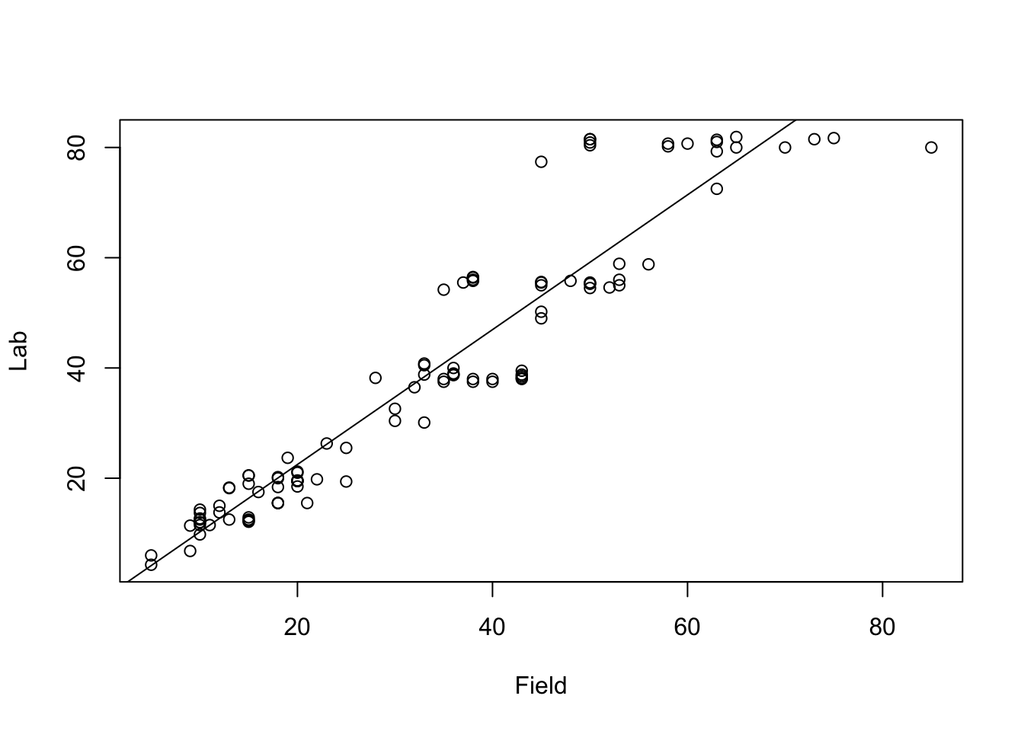

```r
plot(Lab~Field)
abline(pipe_model)
```

2. We can tell there are outliers and variance tends to be bigger from residual versus fitted plot. ncvTest tells us we should reject null hypothesis which means variance is not constant.

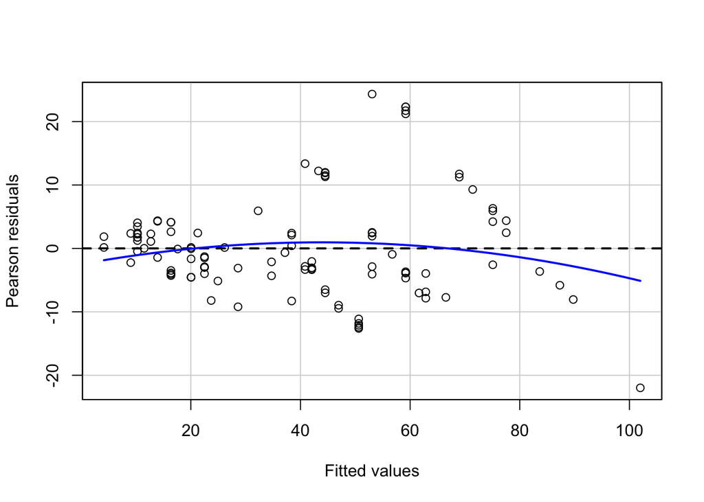

```r
residualPlot(pipe_model)
```

```r
ncvTest(pipe_model)
```

```
## Non-constant Variance Score Test
## Variance formula: ~ fitted.values
## Chisquare = 29.58568, Df = 1, p = 5.3499e-08
```

## Problem4

1. Each variable and overall Tukey test aren’t significant which means this model contains curvature but it can fit enough.

```r
head(water)
```

```
##   Year APMAM APSAB APSLAKE OPBPC  OPRC OPSLAKE  BSAAM
## 1 1948  9.13  3.58    3.91  4.10  7.43    6.47  54235
## 2 1949  5.28  4.82    5.20  7.55 11.11   10.26  67567
## 3 1950  4.20  3.77    3.67  9.52 12.20   11.35  66161
## 4 1951  4.60  4.46    3.93 11.14 15.15   11.13  68094
## 5 1952  7.15  4.99    4.88 16.34 20.05   22.81 107080
## 6 1953  9.70  5.65    4.91  8.88  8.15    7.41  67594
```

```r
attach(water)
water_reg = lm(log(BSAAM)~log(APMAM)+log(APSAB)+log(APSLAKE)+log(OPBPC)+log(OPRC)+log(OPSLAKE))
summary(water_reg)
```

```
##
## Call:
## lm(formula = log(BSAAM) ~ log(APMAM) + log(APSAB) + log(APSLAKE) +
##     log(OPBPC) + log(OPRC) + log(OPSLAKE))
##
## Residuals:
##      Min       1Q   Median       3Q      Max
## -0.18671 -0.05264 -0.00693  0.06130  0.17698
##
## Coefficients:
##              Estimate Std. Error t value Pr(>|t|)
## (Intercept)   9.46675    0.12354  76.626  < 2e-16 ***
## log(APMAM)   -0.02033    0.06596  -0.308  0.75975
## log(APSAB)   -0.10303    0.08939  -1.153  0.25667
## log(APSLAKE)  0.22060    0.08955   2.463  0.01868 *
## log(OPBPC)    0.11135    0.08169   1.363  0.18134
## log(OPRC)     0.36165    0.10926   3.310  0.00213 **
## log(OPSLAKE)  0.18613    0.13141   1.416  0.16524
## ---
## Signif. codes:  0 '***' 0.001 '**' 0.01 '*' 0.05 '.' 0.1 ' ' 1
##
## Residual standard error: 0.1017 on 36 degrees of freedom
## Multiple R-squared:  0.9098, Adjusted R-squared:  0.8948
## F-statistic: 60.54 on 6 and 36 DF,  p-value: < 2.2e-16
```

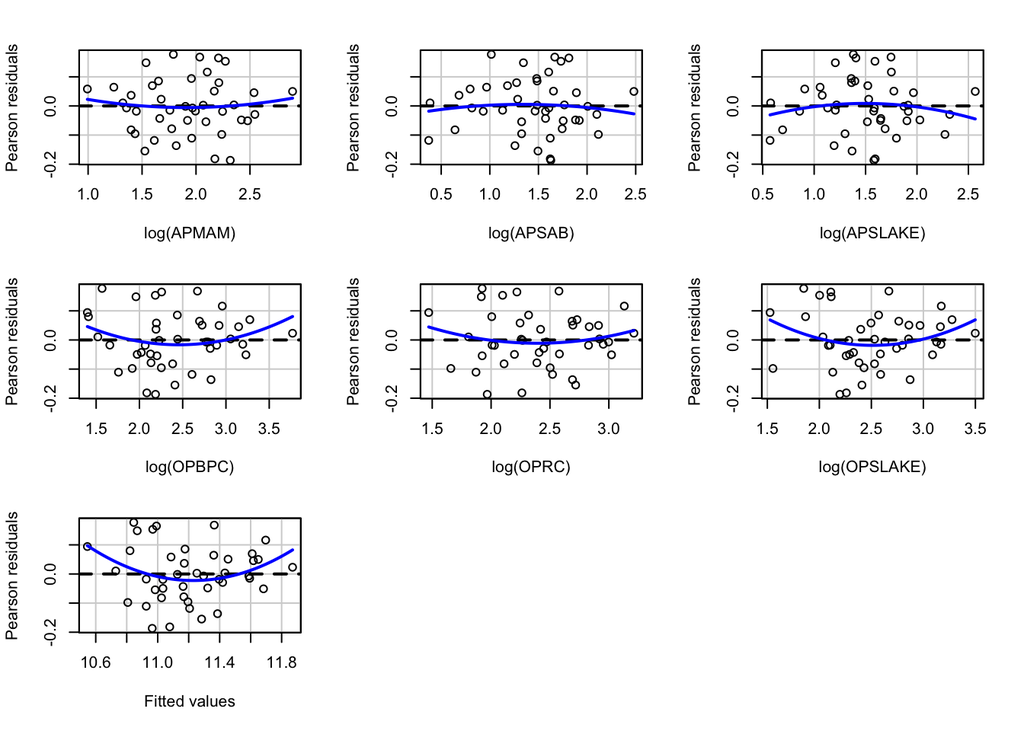

```
##              Test stat Pr(>|Test stat|)
## log(APMAM)      0.4499          0.65553
## log(APSAB)     -0.4647          0.64502
## log(APSLAKE)   -0.8525          0.39976
## log(OPBPC)      1.3848          0.17487
## log(OPRC)       0.8387          0.40735
## log(OPSLAKE)    1.6295          0.11217
## Tukey test      1.8386          0.06597 .
## ---
## Signif. codes:  0 '***' 0.001 '**' 0.01 '*' 0.05 '.' 0.1 ' ' 1
```

```r
residualPlots(water_reg)
```

## Problem5

$E=(y_i-\hat{y}_{i(i)}|X)=\delta$

$H_0:\delta=0, H_a:\delta\not=0$

No.3 and 4 datas can reject null hypothesis which means these are outlier.

```r
n = 54
p = 5
std = 4
error = c(1,1.732,9,10.295)
hat_diag = c(0.9,0.75,0.25,0.185)
standard_resid = error/(std*sqrt(1-hat_diag))
student_resid = standard_resid*sqrt((n-p-1)/(n-p-(standard_resid)^2))
dffits = (1/p)*(standard_resid)^2*(hat_diag/(1-hat_diag))
df = data.frame(error, hat_diag, standard_resid, student_resid, dffits)
df
```

```
##    error hat_diag standard_resid student_resid    dffits
## 1  1.000    0.900      0.7905694     0.7874992 1.1250000
## 2  1.732    0.750      0.8660000     0.8637532 0.4499736
## 3  9.000    0.250      2.5980762     2.7692308 0.4500000
## 4 10.295    0.185      2.8509366     3.0895439 0.3689939
```

```r
2*pt(standard_resid, n-p-1, lower.tail = FALSE)
```

```
## [1] 0.433084054 0.390798264 0.012412713 0.006407767
```